# What a ZIP Code Is, and What It Is Not

A routing key for mail trucks, and everything it gets asked to stand for

Democracy’s Data

Last updated September 13, 2026 at 10:53a EDT

The ZIP code is the only piece of geography most Americans know about themselves. Ask for a census tract and you get a blank look; ask for a ZIP code and you get five digits, instantly and correctly. So surveys collect it, insurers price by it, health studies report by it, and when a news story says life expectancy differs by twenty years between two neighborhoods, the “neighborhoods” are usually two ZIP codes. A large share of the numbers American journalism and research attach to places arrives sorted into these five-digit boxes.

The Postal Service invented the ZIP code in 1963 to route mail,[^1] and a letter addressed to 20500 reaches the White House because the routing works. Everything else the five digits are asked to do rests on an assumption: that a ZIP code is a place, with ground, edges and residents. So what is a ZIP code, actually? And what happens to a statistic when you treat one as a place? Both can be answered from the record.

## The test

Two national lists both answer to the words “ZIP code”, and the test of this brief is the gap between them. The first is the Postal Service’s list of **routing keys**. A code is a label on a bundle of delivery stops, a carrier’s route, a bank of post office boxes, or one office tower, and it is revised whenever revising it moves mail more efficiently. The second is the Census Bureau’s list of **areas**: the 2020 [ZIP Code Tabulation Areas](https://www.census.gov/programs-surveys/geography/guidance/geo-areas/zctas.html), or ZCTAs, the Bureau’s drawn approximation of where each code’s mail goes. Every map of ZIP codes you have seen is the second list. Almost every claim made about ZIP codes is about the first.

The gap can be measured, because the Bureau publishes its own account of the second list. The [2020 ZCTA relationship files](https://www2.census.gov/geo/docs/maps-data/data/rel2020/zcta520/) record, in square metres, how every tabulation area divides among counties, states and cities, and the 2020 census reports every one’s population. The routing-key side comes from [GeoNames’ open compilation of postal codes](https://download.geonames.org/export/zip/US.zip), as it stood in August 2026, because the Postal Service sells its own register rather than publishing it. Census units nest exactly, with a block inside a tract inside a county inside a state; that ladder, and why counts climb it without error, is the subject of the census geography chapter. ZIP codes were built outside the ladder, so how well they fit it is not a matter of definition. It has to be measured.

## The data

The tables below were built from those files, and the two lists are the first of them, `lists.csv`:

| List | What it is | Count |
| --- | --- | --- |
| postal codes in circulation | routing keys, compiled from mail addresses | 41,488 |
| ZIP Code Tabulation Areas | areas, built from census blocks | 33,791 |
| in both | a code that is also an area | 33,642 |
| postal code with no tabulation area | a code that names no ground at all | 7,846 |
| tabulation area with no postal code | ground the compilation does not list | 149 |

Every code in every table is held as text, never as a number, because 00601 read as a number becomes 601 and stops existing. The gap between the two counts above is not rounding, and measuring what falls into it is most of what follows. The rest of the difference between the two objects fits in one table, `zip_vs_zcta.csv`:

|  | ZIP code | ZCTA |
| --- | --- | --- |
| What is it? | a label on a set of delivery addresses | an area made of whole census blocks |
| Who defines it? | U.S. Postal Service | U.S. Census Bureau |
| How does it exist in a file? | a field on each address point | a polygon |
| How many are there? | 41,488 | 33,791 |
| How many have no counterpart? | 7,846 have no tabulation area | 149 carry a code no longer in circulation |
| Where does its edge fall? | nowhere – it has no edge | on a census block boundary, always |
| When does it change? | whenever routing changes | once, at each decennial census |
| Does it cover the country? | only where mail is delivered | inhabited land; empty pieces over 2 sq mi are left out |
| Does it have a population? | no – nobody counts delivery stops | yes – the census count of its blocks |

The Bureau makes an area out of a routing key by a stated procedure. Each census block takes the ZIP code carried by the most addresses inside it; blocks with the same answer are glued together; the glued shape takes the five digits. A block split between two codes goes wholly to one, so the minority side of every such block is gone. A code that never wins a block gets no area at all. Uninhabited stretches larger than two square miles may be left out, and only codes valid on 1 January 2020 were used.

The population of a tabulation area is a real census count: 334,726,586 people were counted inside one in 2020. It is still a count of the Bureau’s blocks, not of the Postal Service’s code, and a second federal source reads the same areas differently. The American Community Survey, the Bureau’s continuous sample survey, which projects a figure from the households it asks rather than counting everyone, gives an estimate for the same 31,972 areas three years later, and it differs from the census count by a median of 6.0%: half the areas differ by less than that, half by more. Neither is wrong; “the population of ZIP code 15217” simply has more than one published answer.

> **Before you read on, commit to a number.** There are 41,488 ZIP codes in circulation. Some of them cannot be drawn as areas at all, because the addresses they serve cover no territory: a single office tower, a wall of post office boxes, a mail channel that follows the Navy. **What share of the 41,488 do you think those are?** One in a thousand? One in a hundred? Write a percentage down before you read on.

## What it says about democracy

**7,846 of the 41,488 codes name no ground at all, or 18.9%.** Close to one in five. The Bureau does not fail to draw them; there is nothing to draw. 509 are military and diplomatic mail: 09096 is listed at longitude 8.249, latitude 50.083, which is in Germany, an American ZIP code with no American ground under it. 52 states have at least one, led by CA with 791.

| ZIP code | Listed as | What it actually is |
| --- | --- | --- |
| 20500 | Washington, DC | the White House |
| 10118 | New York, NY | the Empire State Building |
| 12345 | Schenectady, NY | General Electric, Schenectady |
| 20898 | Gaithersburg, MD | boxes rented at one Maryland post office |
| 09096 | APO AE | Army and Air Force post office, Europe |

The consequence for analysis is specific. Join a table keyed by ZIP code to a table of ZIP areas and roughly one row in five silently fails to match, and the failures are not random. They are office buildings, box renters and service members, three specific populations excluded without a warning printed anywhere.

What the codes that remain do map is the postal system itself.

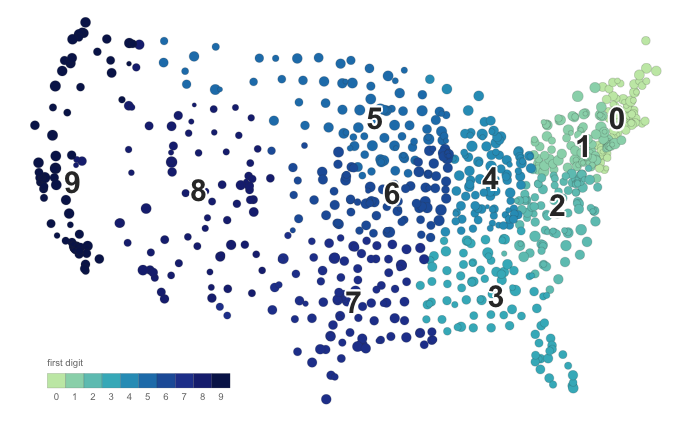

**Figure 1. The mail system, drawn from the data.** One mark per three-digit sorting prefix, 884 of them, placed at the population-weighted centre of the tabulation areas carrying it (the average location of the people, not of the land) and sized by how many areas that is; colour is the leading digit. A dot map fits the question because the postal system is a system of routes and sorting plants, not of areas: nothing here has a boundary to draw. 12 prefixes fall outside the frame, in AK, HI, PR, and are left undrawn rather than moved.

The ten bands are real and coherent, running west from the north-east corner, because a bag routed to area 1 can be sorted again into 15, then 152, then 15213. But it is a map of mail, not of communities, markets or anything drawn with a resident in mind. Every use of a ZIP code as one of those things borrows this figure’s authority for a claim it does not make.

What forcing a delivery route to be a polygon does to a neighborhood is visible where this book is written.

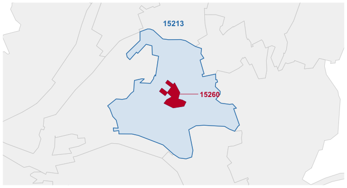

**Figure 2. A ZIP code with two holes in it.** ZIP area 15213 in blue with neighboring areas in gray; the red shape is 15260, which the Bureau drew as 2 disconnected pieces punched out of the middle of 15213.

15213 is Oakland in Pittsburgh: Carnegie Mellon, the museums, most of the University of Pittsburgh’s ground, and 31,075 people counted in 2020. 15260 is the University of Pittsburgh’s *mail*, a code assigned to the university’s own delivery, and its area comes out as two islands of campus buildings holding 29 counted people. No step of this is a mistake; each is a sensible rule correctly applied to a question about delivery. A district drawn to include 15213 has holes in it unless it also takes 15260. A statistic for 15213 describes a neighborhood with its university buildings cut out. Two survey respondents writing 15213 and 15260 may work in the same building.

The same indifference to civic lines shows up at every scale, in the Bureau’s own arithmetic, in `nesting.csv`:

| Counted above | In 2+ counties | % of ZIP areas | In 2+ states | % of people |
| --- | --- | --- | --- | --- |
| 0% | 10,180 | 30.1 | 137 | 25.6 |
| 1% | 9,441 | 27.9 | 117 | 22.1 |
| 5% | 7,675 | 22.7 | 89 | 16.2 |

**10,180 of the 33,791 ZIP areas have land in more than one county**, and 25.6% of everyone living in a ZIP area lives in one of those. 137 cross a state line; the widest reaches into 6 counties. The threshold rows exist because a relationship file records every overlap, including slivers of digitising noise, the hair-thin overlaps left where two boundaries that should coincide do not quite, and raising the bar to five per cent of the area’s own land still leaves 7,675 county-crossers. And a fifth of the country’s land sits under no ZIP area at all, 1,845,990 square kilometres of forest, range and desert the two-square-mile rule lets the Bureau skip.

The boxes do not hold still either. Between the 2010 and 2020 editions of the areas (the Bureau’s word is vintages), 204 codes lost their area and 851 gained one, and of the codes present in both, only 2,028 kept the same shape. The median survivor holds 95.7% of the land it held in 2010. So “15217” in a 2011 file and “15217” in a 2021 file are the same string and not the same place, and nothing in either file says so.

For democracy, the live question is whether these boxes could carry representation. Curiel and Steelman (2018) propose building congressional districts from ZIP codes, on the ground that splitting them damages the link between voters and representatives.[^2] Grofman and Cervas (2021) reply that the unit cannot bear the job.[^3] Both sides can be measured, starting under Pennsylvania’s current map, in `pa_split.csv`:

| Counted above | PA ZIP areas | Split | % of areas | % of people | Most districts |
| --- | --- | --- | --- | --- | --- |
| 1% | 1,833 | 236 | 12.9 | 23.4 | 3 |
| 2% | 1,833 | 223 | 12.2 | 22.6 | 3 |
| 5% | 1,833 | 198 | 10.8 | 19.2 | 3 |

**223 of Pennsylvania’s 1,833 ZIP areas are split between congressional districts, and those areas hold 22.6% of the people**, because a district line through a city runs through the most populous codes. So the harm Curiel and Steelman describe, if it is one, falls on roughly a fifth of Pennsylvanians. But the repair would be built from units that cross counties and occasionally states, arrive with holes and in pieces, change shape without announcement, and are missing entirely for one code in five. Grofman and Cervas add a check on the premise, replicated here. Their fieldwork found pieces of seventeen ZIP codes in Irvine, California, with two wholly inside the city; the Bureau’s relationship file gives 11 and 3 for the same city. The two accounts differ because they count the two different lists, which is this brief’s finding caught in a single number.

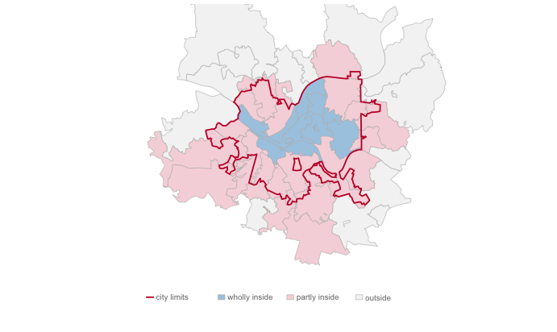

**Figure 3. The City of Pittsburgh, and the ZIP areas that do not fit it.** The city limits in red; each nearby ZIP area shaded by whether it is wholly inside, partly inside, or outside. 32 areas have a real piece of the city and 13 sit wholly within it.

Neither city is unusual. Across the hundred largest American cities, the median city has 20 ZIP areas with land inside it and only 38.4% of them wholly inside, and 4 of the hundred contain not one whole ZIP area. Most states tell their line-drawers, by constitution or statute, to keep counties and cities intact where possible.[^4] A unit that fits neither is a poor brick for a district, however well it routes a letter.

## What this brief cannot tell you

The list of ZIP codes is a compilation, not a register. The Postal Service sells the authoritative file, so the 41,488 counted here come from an open compilation built from address data, and a different compilation would differ in the low hundreds. That the central object of this brief has no free authoritative list is itself a finding.

Everything geographic here is the tabulation area, because the ZIP code has no shape of its own; the Irvine seam shows what that substitution costs. The crossing counts are land, not people, except where a population figure is named. The district measurements cover one state under one map. And nothing here measures what voters actually know: the claim that people cannot draw their own ZIP code’s boundary is Grofman and Cervas’s observation, not a survey result.

## What you should have learned

- A ZIP code is a routing key and a ZCTA is the Census Bureau’s drawn approximation of it, and the difference is measurable: 7,846 of 41,488 codes, 18.9%, have no area at all.
- The population of a ZIP code is really the population of the blocks the Bureau glued under that label, and two federal sources give answers a median of 6.0% apart for the same areas.
- ZIP areas ignore civic geography: 10,180 cross county lines, 137 cross state lines, and only 2,028 kept the same shape across the decade.
- Building districts from ZIP codes would trade a split affecting 22.6% of Pennsylvanians for units with holes, pieces, missing codes and moving edges.
- A statistic computed over ZIP codes stands on boxes drawn to move mail. That is the purest form of the modifiable areal unit problem, the fact that a statistic about areas depends on how the areas were cut.

## Extensions

Every question below can be answered by sorting or grouping in a spreadsheet, using the tables handed over under Sources.

- `no_ground_kind.csv` counts each state’s codes with no area, in its `codes_with_no_ground` and `share_of_state` columns. Which states hold the most, and where is the share of the state’s own codes highest?
- `nesting.csv` reports county-crossing at several values of its `threshold` column. How much does the count in `in_two_or_more_counties` move as the threshold rises, and does `pct_pop_multi_county` move as much?
- `churn.csv` counts the decade’s changes in its `what` and `count` columns. What share of codes present in both vintages came through unchanged?
- `pa_split.csv` carries `pct_split` and `pct_pop_in_split` at each threshold. Why is the population share so much larger than the area share, and what does that say about where district lines run?

Two questions point past the spreadsheet. The relationship files cover every state, so you can download another state’s rows from the address below and ask whether its districts split more or fewer ZIP areas than Pennsylvania’s. And `cities_big.csv` ranks the hundred largest cities by how badly ZIP areas fit them; pick a city you know and find its worst-fitting code.

## Sources

**Data**

- GeoNames, *Postal Codes, United States* — the codes in circulation. A compilation assembled from address data; the authoritative *City State Product* is sold by USPS on subscription. https://download.geonames.org/export/zip/US.zip
- U.S. Census Bureau, *2020 ZCTA relationship files* — how ZCTA land divides among counties, states and places, and how the 2010 areas map to the 2020 ones. https://www2.census.gov/geo/docs/maps-data/data/rel2020/zcta520/
- U.S. Census Bureau, *2020 Census Demographic and Housing Characteristics File*, table P1 at summary level 860 — the decennial count for each tabulation area, from the Bureau’s online data service. https://api.census.gov/data/2020/dec/dhc The Bureau asks for a free key to download from this service, the one source here that does; request one at https://api.census.gov/data/key_signup.html.
- U.S. Census Bureau, *American Community Survey 5-year estimates*, 2023, table B01003 — the second reading of the same areas, and the populations ranking the hundred largest cities. https://www2.census.gov/programs-surveys/acs/summary_file/2023/table-based-SF/data/5YRData/
- U.S. Census Bureau, *Gazetteer Files*, 2024 — each tabulation area’s land area and interior point. https://www2.census.gov/geo/docs/maps-data/data/gazetteer/2024_Gazetteer/
- U.S. Census Bureau, *Cartographic Boundary Files* — the ZCTA, place and congressional district geometry behind the figures. https://www2.census.gov/geo/tiger/GENZ2020/shp/ and https://www2.census.gov/geo/tiger/GENZ2024/shp/
- U.S. Census Bureau, *TIGER/Line Shapefiles, 2020, tabulation blocks* — the Pennsylvania blocks behind the Pittsburgh anatomy. https://www2.census.gov/geo/tiger/TIGER2020/TABBLOCK20/
- U.S. Census Bureau, *ZIP Code Tabulation Areas* — the delineation rules quoted in “The data”. https://www.census.gov/programs-surveys/geography/guidance/geo-areas/zctas.html

**Writing**

- Curiel, J. A., and T. Steelman (2018). “Redistricting Out Representation: Democratic Harms in Splitting Zip Codes.” *Election Law Journal* 17(4): 328–353. https://doi.org/10.1089/elj.2017.0480
- Grofman, B., and J. Cervas (2021). “ZIP Codes as Geographic Bases of Representation.” *Election Law Journal* 20(1). https://doi.org/10.1089/elj.2020.0687
- Openshaw, S. (1984). *The Modifiable Areal Unit Problem.* CATMOG 38. https://alexsingleton.github.io/OpenCATMOG/38-maup-openshaw.pdf

**The data itself**

Every figure above is drawn from these tables. They are plain CSV, they open in a spreadsheet, and they are yours to take further.

`blocks_check.csv`, `churn.csv`, `cities.csv`, `cities_big.csv`, `digit_rows.csv`, `digits.csv`, `lists.csv`, `nesting.csv`, `no_ground.csv`, `no_ground_kind.csv`, `pa_split.csv`, `pgh_blocks.csv`, `pgh_ids.csv`, `pgh_rings.csv`, `scf.csv`, `zip_vs_zcta.csv`

Two more files here are not data about the subject at all – they are how this chapter checked its own work: `facts.csv`, the individual numbers the text above quotes, and `checks.csv`, the arithmetic verified before anything was drawn.

Rebuild this data yourself, with an AI assistant

```
I want to rebuild a public dataset from its original sources, without
any starting files. Please do the following and show your work.

THE SOURCES. Two lists that are usually assumed to be one list, and
the Census Bureau's own account of how they relate. Everything is
open except one request, which needs a free key.
1. GeoNames, "Postal Codes, United States":
   https://download.geonames.org/export/zip/US.zip
   The Postal Service does not give away its own list of ZIP codes;
   it sells it. This CC-BY compilation is the list open work uses
   instead, and it is a compilation, not the register. One row is
   one postal code, tab-delimited, with a place name and a point.
2. U.S. Census Bureau, 2024 Gazetteer, ZIP Code Tabulation Areas:
   https://www2.census.gov/geo/docs/maps-data/data/gazetteer/2024_Gazetteer/2024_Gaz_zcta_national.zip
   One row is one ZCTA -- the Bureau's built-from-blocks
   approximation of a ZIP code -- with its land area and a point.
3. The 2020 Census count for every ZCTA, from the API:
   https://api.census.gov/data/2020/dec/dhc
   with get=P1_001N and for=zip code tabulation area:* (summary
   level 860). THIS ONE NEEDS A KEY. It is free: sign up at
   https://api.census.gov/data/key_signup.html and append &key=...
   to the request.
4. The Bureau's 2020 relationship files, keyless, which record in
   square metres how ZCTAs overlap counties and how the 2010 areas
   became the 2020 ones:
   https://www2.census.gov/geo/docs/maps-data/data/rel2020/zcta520/tab20_zcta520_county20_natl.txt
   https://www2.census.gov/geo/docs/maps-data/data/rel2020/zcta520/tab20_zcta510_zcta520_natl.txt

WHAT TO BUILD.
1. The two lists side by side: how many postal codes are in
   circulation, how many tabulation areas exist, how many codes sit
   on both lists, and how many postal codes have no tabulation area
   at all -- real mail routes that name no ground.
2. The total 2020 population living inside any tabulation area.
3. From the relationship files: how many ZCTAs reach into more than
   one county, and how many into more than one state.

CHECK YOUR WORK. The copies this book used were downloaded in August
2026. If your rebuild matches them, you should find:
- 41,488 postal codes against 33,791 tabulation areas, with 33,642
  codes on both lists and 7,846 postal codes naming no ground
- 334,726,586 people counted inside a tabulation area
- 10,180 ZCTAs reach into two or more counties, and 137 into two or
  more states
The GeoNames compilation moves week to week, so the postal-code side
will drift with the day you download it; the census side is frozen
until the 2030 ZCTAs are drawn. Drift on the first list is the list
changing, not a mistake.
```

[^1]: United States Postal Service, *The United States Postal Service: An American History*, Publication 100 (250th anniversary edition, 2025), on the introduction of the Zone Improvement Plan code in July 1963: https://about.usps.com/publications/pub100.pdf.
[^2]: John A. Curiel and Tyler Steelman, “Redistricting Out Representation: Democratic Harms in Splitting Zip Codes,” *Election Law Journal* 17, no. 4 (2018): 328–353, doi:10.1089/elj.2017.0480.
[^3]: Bernard Grofman and Jonathan Cervas, “ZIP Codes as Geographic Bases of Representation,” *Election Law Journal* 20, no. 1 (2021), doi:10.1089/elj.2020.0687.
[^4]: The Brennan Center’s state-by-state guide lists each state’s redistricting criteria, including which ones require political subdivisions to be kept whole: https://www.brennancenter.org/our-work/research-reports/50-state-guide-redistricting.